# PCSK9-Mediation-MR

Seongwon Hwang

23-11-2026

This report regenerates the estimates, tables and figures of the real-data example: plasma PCSK9 (exposure), LDL-C (mediator) and coronary artery disease (CAD, outcome), analysed by the two-step method and multivariable Mendelian randomisation (MVMR) in two settings.

# Software

All numbers and figures were produced in the conda environment of `environment.yml` (Python 3.12.9, NumPy 2.5.1, SciPy 1.18.0, pandas 3.0.3, R 4.5.3, MendelianRandomization 0.10.0, ggplot2 4.0.4). PLINK v1.90b7.7 was used for clumping and LD.

```bash
conda env create -f environment.yml
# Windows only: install CRAN binaries of four Fortran packages that conda-forge's Windows builds
# sometimes fail to load (see the script)
powershell -ExecutionPolicy Bypass -File scripts/setup_env_windows.ps1
conda activate pcsk9-mr
Rscript -e "rmarkdown::render('PCSK9-Mediation-MR.Rmd')"
```

```r
suppressPackageStartupMessages({
  library(ggplot2)
  library(MendelianRandomization)
})
c(R = R.version.string, MendelianRandomization = as.character(packageVersion("MendelianRandomization")),
  ggplot2 = as.character(packageVersion("ggplot2")))
```

```
##                                   R              MendelianRandomization
## "R version 4.5.3 (2026-03-11 ucrt)"                            "0.10.0"
##                             ggplot2
##                             "4.0.4"
```

# Data and instruments

Plasma PCSK9 associations are the deCODE SomaScan summary for aptamer 5231_79, LDL-C associations the European ancestry GLGC meta-analysis (GCST90239658), and CAD associations the Aragam meta-analysis (GCST90132314). LD is from the 503 European individuals of 1000 Genomes Phase 3. The full summary statistics are not in this repository; `data/README.md` lists them and the scripts that rebuild the variant-level tables in `summary_results`, which are all that this report needs.

```r
summ <- "summary_results"
cis <- read.delim(file.path(summ, "pcsk9_instruments.tsv"), stringsAsFactors = FALSE)
s1 <- read.delim(file.path(summ, "ldl_setting1.tsv"), stringsAsFactors = FALSE)
s2 <- read.delim(file.path(summ, "ldl_setting2.tsv"), stringsAsFactors = FALSE)
removed <- read.delim(file.path(summ, "setting1_removed.tsv"), stringsAsFactors = FALSE)
in_region <- function(d, chr, lo, hi) d$chromosome == chr & d$position >= lo & d$position <= hi
apoe <- function(d) in_region(d, 19, 44409011, 46412650)   # gene +/- 1 Mb, GRCh37
lpa <- function(d) in_region(d, 6, 159952515, 162087407)
data.frame(
  set = c("PCSK9 instruments", "LDL-C, Setting 1", "LDL-C, Setting 2"),
  instruments = c(nrow(cis), nrow(s1), nrow(s2)),
  APOE = c(NA, sum(apoe(s1)), sum(apoe(s2))),
  LPA = c(NA, sum(lpa(s1)), sum(lpa(s2))),
  after_exclusion = c(nrow(cis), sum(!apoe(s1) & !lpa(s1)), sum(!apoe(s2) & !lpa(s2))))
```

```
##                 set instruments APOE LPA after_exclusion
## 1 PCSK9 instruments          16   NA  NA              16
## 2  LDL-C, Setting 1         385   13   9             363
## 3  LDL-C, Setting 2         394   13   9             372
```

```r
removed
```

```
##          rsid chromosome position
## 1  rs11591147          1 55505647
## 2    rs693668          1 55521109
## 3   rs7534572          1 62999675
## 4  rs11206517          1 55526428
## 5 rs374459115          1 55489968
## 6   rs6588577          1 56322645
## 7    rs213499          1 54866285
## 8 rs185543052          1 56214644
## 9  rs11581697          1 61861024
##                                              reason
## 1 inside PCSK9 +/-50 kb or is a cis pQTL instrument
## 2 inside PCSK9 +/-50 kb or is a cis pQTL instrument
## 3                         r2=0.0038 with rs11583974
## 4 inside PCSK9 +/-50 kb or is a cis pQTL instrument
## 5 inside PCSK9 +/-50 kb or is a cis pQTL instrument
## 6                         r2=0.0102 with rs17192725
## 7                         r2=0.0025 with rs45613943
## 8                         r2=0.0084 with rs11810371
## 9                         r2=0.0092 with rs11810371
```

The 16 PCSK9 instruments come from the PCSK9 gene and 50 kb on either side, clumped at r² < 0.1. The 394 genome-wide LDL-C instruments were clumped at r² < 0.001 within 10 Mb. Setting 1 removes the nine LDL-C instruments above: four lie in the PCSK9 window or are PCSK9 instruments, and five have r² of at least 0.001 with a PCSK9 instrument. Setting 2 keeps all 394. In both settings the main analysis removes the LDL-C instruments within 1 Mb of APOE and of LPA, whose effects on CAD do not act only through LDL-C.

The tables were built from the original studies with the commands below (see `data/README.md`).

```bash
python scripts/extract_ldl_gws.py
python scripts/clump_ldl_by_z.py
python scripts/extract_pcsk9_window.py
Rscript scripts/select_cis_instruments.R
python scripts/extract_pcsk9_setting1.py
python scripts/extract_pcsk9_setting2.py
```

# Estimation

`scripts/estimate_effects.py` fits every model. IVW and multivariable IVW are used in their generalised least squares form, with the covariance of the CAD associations equal to diag(SE) R diag(SE), where R is the 1000 Genomes correlation between instruments within 10 Mb of PCSK9 (`region_corr.ld`) and the identity elsewhere, and with multiplicative random effects. The total effect of PCSK9 on CAD and the effect of PCSK9 on LDL-C come from the 16 PCSK9 instruments and are the same in both settings.

- Two-step: the indirect effect is θ<sub>XM</sub>θ<sub>MY</sub> with a delta-method standard error. The direct effect is the total effect minus the indirect effect; its variance subtracts 2 θ<sub>XM</sub> Cov(θ<sub>XY</sub>, θ<sub>MY</sub>). This covariance is zero in Setting 1. In Setting 2 it is positive, because rs11591147 is both a PCSK9 and an LDL-C instrument and other LDL-C instruments near PCSK9 are in LD with the PCSK9 instruments.
- MVMR: the PCSK9 coefficient is the direct effect, and the indirect effect is the total effect minus it, with the covariance of the two in its standard error.
- Covariances come from the weights of the two estimators and the covariance matrix of the CAD associations, each scaled by its random-effects factor. The conditional F statistic is computed with the LD matrix; with two exposures it is the same for LDL-C and PCSK9.

The “independent” sensitivity analysis keeps only the three PCSK9 instruments that are mutually independent at r² < 0.001 and does not model LD; its Setting 2 MVMR also leaves out the LDL-C instruments with r² of at least 0.001 with them.

```r
out <- system2(Sys.which("python"), file.path("scripts", "estimate_effects.py"), stdout = TRUE, stderr = TRUE)
cat(out, sep = "\n")
```

```
## independent PCSK9 instruments: ['rs11591147', 'rs472495', 'rs7525503']
##    analysis   setting         exclusion  n_uni  n_mvmr  total  ldl_cad_uni  direct_twostep  direct_twostep_p  direct_mvmr  direct_mvmr_p  cond_f
##        main Setting 1 APOE+LPA excluded    363     378 0.2349       0.4829          0.0498            0.1096       0.0588         0.0789  5.7538
##        main Setting 1               all    385     400 0.2349       0.4624          0.0576            0.0578       0.0722         0.0522  5.7375
##        main Setting 2 APOE+LPA excluded    372     384 0.2349       0.4872          0.0481            0.0892       0.0529         0.1033  5.9364
##        main Setting 2               all    394     406 0.2349       0.4665          0.0561            0.0477       0.0656         0.0692  5.9202
## independent Setting 1 APOE+LPA excluded    363     365 0.2430       0.4829          0.0530            0.0769       0.0619         0.0816  5.4101
## independent Setting 2 APOE+LPA excluded    372     368 0.2430       0.4866          0.0515            0.0679       0.0582         0.0929  5.5685
## wrote G:\projects\PCSK9-Mediation-MR\results\estimates
```

```r
est <- read.delim(file.path("results", "estimates", "estimates.tsv"), stringsAsFactors = FALSE)
```

`summary_results/estimates.tsv` is the table written for the paper. The run above reproduces it exactly:

```r
stored <- read.delim(file.path(summ, "estimates.tsv"), colClasses = "character")
now <- read.delim(file.path("results", "estimates", "estimates.tsv"), colClasses = "character")
identical(stored, now)
```

```
## [1] TRUE
```

```r
minus <- function(x) gsub("-", "−", x, fixed = TRUE)
f3 <- function(x) minus(sprintf("%.3f", x))
ci <- function(e, s) sprintf("%s (%s to %s)", f3(e), f3(e - 1.96 * s), f3(e + 1.96 * s))
pv <- function(p) {
  if (p >= 0.001) return(formatC(p, digits = 2, format = "fg", flag = "#"))
  k <- floor(log10(p)); m <- p / 10^k
  if (round(m, 1) >= 10) { m <- m / 10; k <- k + 1 }
  sprintf("%.1f &times; 10<sup>&minus;%d</sup>", m, -k)
}
pick <- function(analysis, setting, exclusion)
  est[est$analysis == analysis & est$setting == setting & est$exclusion == exclusion, ]
row <- function(label, q, r1, r2)
  data.frame(Quantity = label, `Setting 1` = ci(r1[[q]], r1[[paste0(q, "_se")]]), P = pv(r1[[paste0(q, "_p")]]),
             `Setting 2` = ci(r2[[q]], r2[[paste0(q, "_se")]]), `P ` = pv(r2[[paste0(q, "_p")]]), check.names = FALSE)
head_row <- function(label)
  data.frame(Quantity = paste0("<b>", label, "</b>"), `Setting 1` = "", P = "", `Setting 2` = "", `P ` = "",
             check.names = FALSE)
m1 <- pick("main", "Setting 1", "APOE+LPA excluded"); m2 <- pick("main", "Setting 2", "APOE+LPA excluded")
```

# Table 3

Estimates in Setting 1 and Setting 2, with the LDL-C instruments in the APOE and LPA regions excluded and LD among instruments within 10 Mb of PCSK9 accounted for. Log odds ratios for CAD per SD higher PCSK9 or LDL-C; SD of LDL-C per SD higher PCSK9.

```r
t3 <- rbind(
  head_row("PCSK9 on CAD"),
  row("Total effect, univariable IVW", "total", m1, m2),
  row("Indirect effect, two-step", "indirect_twostep", m1, m2),
  row("Indirect effect, MVMR", "indirect_mvmr", m1, m2),
  row("Direct effect, two-step", "direct_twostep", m1, m2),
  row("Direct effect, MVMR", "direct_mvmr", m1, m2),
  head_row("PCSK9 on LDL-C"),
  row("Total effect, univariable IVW", "pcsk9_ldl", m1, m2),
  head_row("LDL-C on CAD"),
  row("Univariable IVW, for the two-step method", "ldl_cad_uni", m1, m2),
  row("MVMR, adjusted for PCSK9", "ldl_cad_mvmr", m1, m2))
knitr::kable(t3, escape = FALSE, align = "lllll")
```

| Quantity | Setting 1 | P | Setting 2 | P |
| --- | --- | --- | --- | --- |
| **PCSK9 on CAD** |  |  |  |  |
| Total effect, univariable IVW | 0.235 (0.188 to 0.282) | 2.7 × 10<sup>−22</sup> | 0.235 (0.188 to 0.282) | 2.7 × 10<sup>−22</sup> |
| Indirect effect, two-step | 0.185 (0.147 to 0.224) | 2.9 × 10<sup>−21</sup> | 0.187 (0.149 to 0.224) | 2.3 × 10<sup>−22</sup> |
| Indirect effect, MVMR | 0.176 (0.129 to 0.224) | 3.1 × 10<sup>−13</sup> | 0.182 (0.135 to 0.229) | 5.4 × 10<sup>−14</sup> |
| Direct effect, two-step | 0.050 (−0.011 to 0.111) | 0.11 | 0.048 (−0.007 to 0.104) | 0.089 |
| Direct effect, MVMR | 0.059 (−0.007 to 0.124) | 0.079 | 0.053 (−0.011 to 0.117) | 0.10 |
| **PCSK9 on LDL-C** |  |  |  |  |
| Total effect, univariable IVW | 0.383 (0.324 to 0.443) | 3.9 × 10<sup>−36</sup> | 0.383 (0.324 to 0.443) | 3.9 × 10<sup>−36</sup> |
| **LDL-C on CAD** |  |  |  |  |
| Univariable IVW, for the two-step method | 0.483 (0.417 to 0.549) | 4.2 × 10<sup>−47</sup> | 0.487 (0.425 to 0.549) | 2.0 × 10<sup>−53</sup> |
| MVMR, adjusted for PCSK9 | 0.470 (0.401 to 0.538) | 2.6 × 10<sup>−41</sup> | 0.467 (0.399 to 0.535) | 1.3 × 10<sup>−41</sup> |

```r
data.frame(setting = c("Setting 1", "Setting 2"),
           LDL_C_instruments = c(m1$n_uni, m2$n_uni), variants_in_MVMR = c(m1$n_mvmr, m2$n_mvmr),
           mediated_two_step = sprintf("%.0f%%", c(m1$pct_mediated_twostep, m2$pct_mediated_twostep)),
           mediated_MVMR = sprintf("%.0f%%", c(m1$pct_mediated_mvmr, m2$pct_mediated_mvmr)),
           conditional_F = sprintf("%.1f", c(m1$cond_f, m2$cond_f)),
           corr_total_vs_LDL_C_on_CAD = round(c(m1$corr_total_ldl_cad, m2$corr_total_ldl_cad), 3))
```

```
##     setting LDL_C_instruments variants_in_MVMR mediated_two_step mediated_MVMR
## 1 Setting 1               363              378               79%           75%
## 2 Setting 2               372              384               80%           77%
##   conditional_F corr_total_vs_LDL_C_on_CAD
## 1           5.8                       0.00
## 2           5.9                       0.26
```

# Supplementary Table S2

Sensitivity analyses. The first uses all LDL-C instruments and models LD as in the main analysis. The second uses the three independent PCSK9 instruments and the LDL-C instruments of the main analysis without modelling LD; the covariance of its Setting 2 two-step direct effect then comes only from rs11591147, which enters both the total effect and the effect of LDL-C on CAD.

```r
a1 <- pick("main", "Setting 1", "all"); a2 <- pick("main", "Setting 2", "all")
i1 <- pick("independent", "Setting 1", "APOE+LPA excluded"); i2 <- pick("independent", "Setting 2", "APOE+LPA excluded")
s2tab <- rbind(
  head_row("All LDL-C instruments"),
  row("LDL-C on CAD, univariable IVW", "ldl_cad_uni", a1, a2),
  row("Direct effect, two-step", "direct_twostep", a1, a2),
  row("Direct effect, MVMR", "direct_mvmr", a1, a2),
  head_row("APOE and LPA regions excluded, three independent PCSK9 instruments, LD not accounted for"),
  row("LDL-C on CAD, univariable IVW", "ldl_cad_uni", i1, i2),
  row("Direct effect, two-step", "direct_twostep", i1, i2),
  row("Direct effect, MVMR", "direct_mvmr", i1, i2))
knitr::kable(s2tab, escape = FALSE, align = "lllll")
```

| Quantity | Setting 1 | P | Setting 2 | P |
| --- | --- | --- | --- | --- |
| **All LDL-C instruments** |  |  |  |  |
| LDL-C on CAD, univariable IVW | 0.462 (0.402 to 0.522) | 1.4 × 10<sup>−51</sup> | 0.467 (0.409 to 0.524) | 1.3 × 10<sup>−56</sup> |
| Direct effect, two-step | 0.058 (−0.002 to 0.117) | 0.058 | 0.056 (0.001 to 0.112) | 0.048 |
| Direct effect, MVMR | 0.072 (−0.001 to 0.145) | 0.052 | 0.066 (−0.005 to 0.136) | 0.069 |
| **APOE and LPA regions excluded, three independent PCSK9 instruments, LD not accounted for** |  |  |  |  |
| LDL-C on CAD, univariable IVW | 0.483 (0.417 to 0.549) | 4.2 × 10<sup>−47</sup> | 0.487 (0.425 to 0.549) | 2.5 × 10<sup>−53</sup> |
| Direct effect, two-step | 0.053 (−0.006 to 0.112) | 0.077 | 0.051 (−0.004 to 0.107) | 0.068 |
| Direct effect, MVMR | 0.062 (−0.008 to 0.132) | 0.082 | 0.058 (−0.010 to 0.126) | 0.093 |

```r
c(independent_total_effect = ci(i1$total, i1$total_se), independent_PCSK9_on_LDL_C = ci(i1$pcsk9_ldl, i1$pcsk9_ldl_se))
```

```
##   independent_total_effect independent_PCSK9_on_LDL_C
##   "0.243 (0.205 to 0.281)"   "0.394 (0.318 to 0.469)"
```

The effect of LDL-C on CAD by IVW within the two excluded regions and outside them, in Setting 1:

```r
reg <- read.delim(file.path("results", "estimates", "region_ivw.tsv"), stringsAsFactors = FALSE)
transform(reg, ldl_cad_ivw = round(ldl_cad_ivw, 2), se = round(se, 3))
```

```
##     setting          instruments   n ldl_cad_ivw    se
## 1 Setting 1          APOE region  13        0.30 0.022
## 2 Setting 1           LPA region   9        2.13 0.330
## 3 Setting 1 outside APOE and LPA 363        0.48 0.033
```

The APOE instruments give a smaller effect than the others and the LPA instruments a much larger one, so including both regions changes the effect of LDL-C on CAD only slightly (from 0.483 to 0.462 in Setting 1).

# Check against MendelianRandomization

The Python estimators are refitted here with `mr_ivw` and `mr_mvivw` (random effects; `correl = TRUE` with the same correlation matrix, or no correlation for the independent analysis). The two-step direct effect and the MVMR indirect effect are differences of these estimates; their covariance terms are computed in the Python script.

```r
bim <- read.table(file.path(summ, "region_snps.bim"), sep = "\t", col.names = c("chr", "rsid", "cm", "bp", "a1", "a2"))
R <- as.matrix(read.table(file.path(summ, "region_corr.ld"), sep = "\t"))
R[upper.tri(R)] <- t(R)[upper.tri(R)]
eff <- c(setNames(cis$effect_allele, cis$rsid), setNames(s2$effect_allele, s2$rsid))
sgn <- ifelse(toupper(eff[bim$rsid]) == toupper(bim$a1), 1, -1)   # align r to the LDL-C effect allele
R <- R * outer(sgn, sgn)
dimnames(R) <- list(bim$rsid, bim$rsid)
corr <- function(ids) {
  C <- diag(length(ids)); inp <- ids %in% bim$rsid
  C[inp, inp] <- R[ids[inp], ids[inp]]; diag(C) <- 1; C
}
r2_to <- function(ids, targets)
  sapply(ids, function(r) if (r %in% bim$rsid) max(R[r, intersect(targets, bim$rsid)]^2) else 0)
ivw <- function(bx, bxse, by, byse, C) {
  inp <- if (is.null(C)) mr_input(bx = bx, bxse = bxse, by = by, byse = byse)
         else mr_input(bx = bx, bxse = bxse, by = by, byse = byse, correlation = C)
  f <- mr_ivw(inp, model = "random", correl = !is.null(C)); as.numeric(c(f@Estimate, f@StdError))
}
refit <- function(cisd, d, ld, mv_cut) {
  ids <- cisd$rsid
  C <- function(x) if (ld) corr(x) else NULL
  tot <- ivw(cisd$beta_pqtl, cisd$se_pqtl, cisd$beta_cad, cisd$se_cad, C(ids))
  xm <- ivw(cisd$beta_pqtl, cisd$se_pqtl, cisd$beta_ldl, cisd$se_ldl, C(ids))
  uni <- ivw(d$beta_ldl, d$se_ldl, d$beta_cad, d$se_cad, C(d$rsid))
  g <- d[!is.na(d$beta_pqtl) & !(d$rsid %in% ids), ]
  g <- g[r2_to(g$rsid, ids) < mv_cut, ]
  cols <- c("rsid", "beta_ldl", "se_ldl", "beta_cad", "se_cad", "beta_pqtl", "se_pqtl")
  v <- rbind(g[, cols], cisd[, cols])
  mv <- if (ld) mr_mvinput(bx = cbind(v$beta_ldl, v$beta_pqtl), bxse = cbind(v$se_ldl, v$se_pqtl),
                           by = v$beta_cad, byse = v$se_cad, correlation = corr(v$rsid))
        else mr_mvinput(bx = cbind(v$beta_ldl, v$beta_pqtl), bxse = cbind(v$se_ldl, v$se_pqtl),
                        by = v$beta_cad, byse = v$se_cad)
  f <- mr_mvivw(mv, model = "random", correl = ld)
  b <- as.numeric(f@Estimate); s <- as.numeric(f@StdError)
  c(total = tot[1], total_se = tot[2], pcsk9_ldl = xm[1], pcsk9_ldl_se = xm[2],
    ldl_cad_uni = uni[1], ldl_cad_uni_se = uni[2], ldl_cad_mvmr = b[1], ldl_cad_mvmr_se = s[1],
    direct_mvmr = b[2], direct_mvmr_se = s[2], n_uni = nrow(d), n_mvmr = nrow(v))
}
keep <- function(d) d[!apoe(d) & !lpa(d), ]
z <- abs(cis$beta_pqtl / cis$se_pqtl); cis3 <- character(0)
for (r in cis$rsid[order(-z)]) if (length(cis3) == 0 || max(R[r, cis3]^2) < 0.001) cis3 <- c(cis3, r)
cis3d <- cis[cis$rsid %in% cis3, ]
fits <- list(
  list("main", "Setting 1", "APOE+LPA excluded", refit(cis, keep(s1), TRUE, 0.1)),
  list("main", "Setting 2", "APOE+LPA excluded", refit(cis, keep(s2), TRUE, 0.1)),
  list("main", "Setting 1", "all", refit(cis, s1, TRUE, 0.1)),
  list("main", "Setting 2", "all", refit(cis, s2, TRUE, 0.1)),
  list("independent", "Setting 1", "APOE+LPA excluded", refit(cis3d, keep(s1), FALSE, 0.001)),
  list("independent", "Setting 2", "APOE+LPA excluded", refit(cis3d, keep(s2), FALSE, 0.001)))
quant <- c("total", "total_se", "pcsk9_ldl", "pcsk9_ldl_se", "ldl_cad_uni", "ldl_cad_uni_se",
           "ldl_cad_mvmr", "ldl_cad_mvmr_se", "direct_mvmr", "direct_mvmr_se")
do.call(rbind, lapply(fits, function(x) {
  e <- pick(x[[1]], x[[2]], x[[3]])
  data.frame(analysis = x[[1]], setting = x[[2]], exclusion = x[[3]],
             same_instrument_counts = all(x[[4]][c("n_uni", "n_mvmr")] == unlist(e[c("n_uni", "n_mvmr")])),
             largest_abs_difference = signif(max(abs(x[[4]][quant] - unlist(e[quant]))), 2))
}))
```

```
##      analysis   setting         exclusion same_instrument_counts
## 1        main Setting 1 APOE+LPA excluded                   TRUE
## 2        main Setting 2 APOE+LPA excluded                   TRUE
## 3        main Setting 1               all                   TRUE
## 4        main Setting 2               all                   TRUE
## 5 independent Setting 1 APOE+LPA excluded                   TRUE
## 6 independent Setting 2 APOE+LPA excluded                   TRUE
##   largest_abs_difference
## 1                4.7e-07
## 2                4.7e-07
## 3                4.7e-07
## 4                4.7e-07
## 5                3.0e-07
## 6                3.0e-07
```

The differences are at the sixth significant digit, where `estimates.tsv` is rounded.

# Figure 1

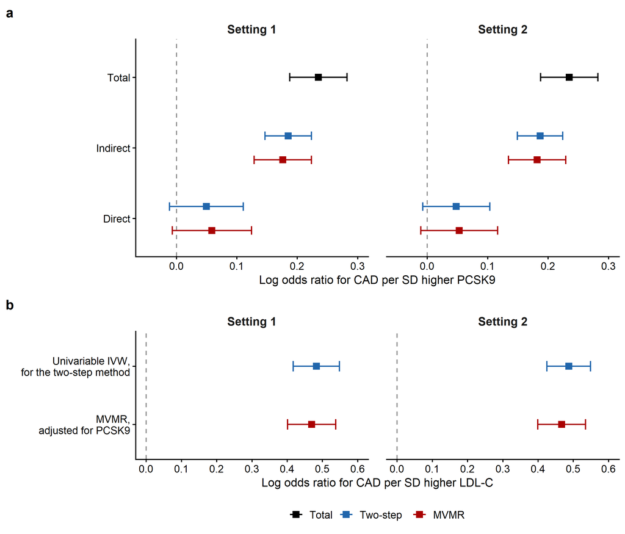

```r
invisible(system2(file.path(R.home("bin"), "Rscript"), file.path("scripts", "figure1.R"), stdout = TRUE))
knitr::include_graphics(file.path("results", "figures", "Figure1.png"))
```

Effects of PCSK9 and LDL-C on CAD in Setting 1 and Setting 2. (a) Total effect of PCSK9 on CAD and its indirect and direct effects from the two-step method and MVMR. (b) Effect of LDL-C on CAD from univariable IVW, for the two-step method, and from MVMR adjusted for PCSK9. LDL-C instruments in the APOE and LPA regions were excluded, and LD among instruments within 10 Mb of PCSK9 was accounted for. Squares are estimates and bars are 95% confidence intervals.

# Correlations between instruments

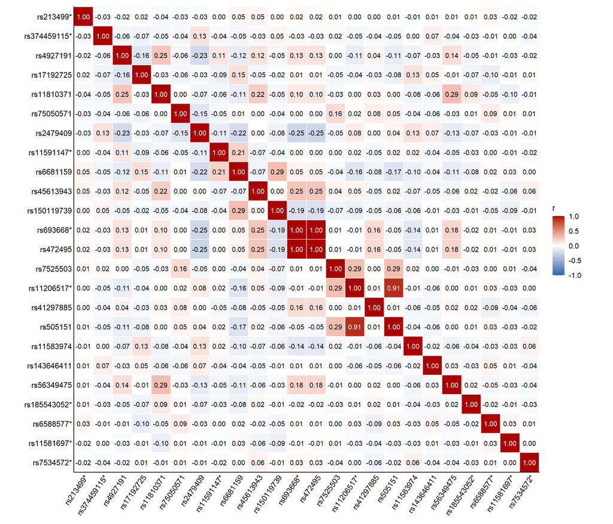

```r
invisible(system2(file.path(R.home("bin"), "Rscript"), file.path("scripts", "figureS1.R"), stdout = TRUE))
knitr::include_graphics(file.path("results", "figures", "FigureS1.png"))
```

Supplementary Figure S1. Correlations (r) between the 16 PCSK9 instruments and the 9 Setting 2 LDL-C instruments within 10 Mb of PCSK9 (asterisks), aligned to the LDL-C effect allele. rs11591147 belongs to both sets, so 24 variants are shown. This is the correlation matrix used in the estimation; rs693668 and rs11206517 were left out of the MVMR.

```r
pc <- R[cis$rsid, cis$rsid][upper.tri(diag(16))]
c(PCSK9_pairs = length(pc), pairs_abs_r_above_0.1 = sum(abs(pc) > 0.1), largest_abs_r = round(max(abs(pc)), 2),
  rs693668_rs472495 = round(R["rs693668", "rs472495"], 2), rs11206517_rs505151 = round(R["rs11206517", "rs505151"], 2))
```

```
##           PCSK9_pairs pairs_abs_r_above_0.1         largest_abs_r
##                120.00                 32.00                  0.29
##     rs693668_rs472495   rs11206517_rs505151
##                  1.00                  0.91
```

```r
lb <- read.table(file.path(summ, "ldl_snps.bim"), sep = "\t", col.names = c("chr", "rsid", "cm", "bp", "a1", "a2"))
L <- as.matrix(read.table(file.path(summ, "ldl_corr.ld"), sep = "\t"))
L[upper.tri(L)] <- t(L)[upper.tri(L)]; diag(L) <- 0
k <- which(abs(L) == max(abs(L), na.rm = TRUE), arr.ind = TRUE)[1, ]
c(LDL_C_instruments = nrow(lb), largest_abs_r = round(max(abs(L), na.rm = TRUE), 2),
  between = paste(lb$rsid[k], "chr", lb$chr[k], collapse = " and "))
```

```
##                          LDL_C_instruments
##                                      "394"
##                              largest_abs_r
##                                     "0.23"
##                                    between
## "rs147211387 chr 19 and rs543486395 chr 5"
```